# Más Allá de la Predicción: Simulaciones para Entender el Abandono en Salud Mental

## Descarga de datos y EDA inicial

### Dataset

Este notebook utiliza el dataset:  
**Mental health condition and lifestyle dataset**  
Fuente: [Zenodo - DOI: 10.5281/zenodo.14838680](https://doi.org/10.5281/zenodo.14838680)  
Data Manager: Pandey, B. (2024). Fecha de descarga: 1 de agosto de 2025  
Licencia: Creative Commons Attribution 4.0 International (CC BY 4.0)

## 1. Configuración y librerías necesarias

```python
import os, sys, math, json, warnings
warnings.filterwarnings("ignore")

import numpy as np
import pandas as pd

import matplotlib.pyplot as plt
import seaborn as sns
import missingno as msno

from scipy import stats
from scipy.stats import chi2_contingency, kruskal
from itertools import combinations

plt.rcParams["figure.figsize"] = (7,4)
plt.rcParams["axes.grid"] = True

# Carpetas de salida
os.makedirs("out", exist_ok=True)
os.makedirs("fig", exist_ok=True)

# Funciones utilitarias
def memory_reduce(df: pd.DataFrame) -> pd.DataFrame:
    for col in df.select_dtypes(include=["int64","int32","int16"]).columns:
        df[col] = pd.to_numeric(df[col], downcast="integer")
    for col in df.select_dtypes(include=["float64","float32"]).columns:
        df[col] = pd.to_numeric(df[col], downcast="float")
    return df

def to_category(df, cols):
    for c in cols:
        if c in df.columns:
            df[c] = df[c].astype("category")
    return df

def iqr_outlier_mask(s: pd.Series, k: float = 1.5):
    q1, q3 = s.quantile([0.25, 0.75])
    iqr = q3 - q1
    lower, upper = q1 - k*iqr, q3 + k*iqr
    return (s < lower) | (s > upper)

def wilson_ci(k, n, z=1.96):
    if n == 0: return (np.nan, np.nan)
    p = k/n
    denom = 1 + z**2/n
    center = (p + z**2/(2*n))/denom
    margin = (z*math.sqrt((p*(1-p) + z**2/(4*n))/n))/denom
    return center - margin, center + margin

def cramers_v(table: pd.DataFrame):
    chi2, p, dof, exp = chi2_contingency(table)
    n = table.values.sum()
    r, c = table.shape
    return math.sqrt(chi2 / (n * (min(r-1, c-1) or 1))), p

def savefig(path):
    plt.tight_layout()
    plt.savefig(path, bbox_inches="tight", dpi=150)
    plt.show()
```

## 2. Carga de datos y chequeos básicos

```python
# Carga
DATA_PATH = "data/mental_health_data final data.csv"
df = pd.read_csv(DATA_PATH)

# Resumen inicial
n_rows, n_cols = df.shape
print(f"Registros: {n_rows:,} | Columnas: {n_cols}")
display(df.head(3))
display(df.info())

# Tipos esperados
num_cols = [
    "Age", "Sleep_Hours", "Work_Hours",
    "Physical_Activity_Hours", "Social_Media_Usage"
]
cat_cols = [
    "Gender", "Occupation", "Country", "Mental_Health_Condition",
    "Severity", "Consultation_History", "Stress_Level",
    "Diet_Quality", "Smoking_Habit", "Alcohol_Consumption",
    "Medication_Usage"
]

# Verificación de columnas
missing_cols = [c for c in num_cols + cat_cols if c not in df.columns]
if missing_cols:
    print("Faltan columnas esperadas:", missing_cols)
else:
    print("Todas las columnas esperadas están presentes")

# Casts y reducción de memoria
# Convertimos todas las object a category y optimizamos numéricas
df = to_category(df, cat_cols + [c for c in df.columns if df[c].dtype == "object"])
df = memory_reduce(df)

# Duplicados
dups = df.duplicated().sum()
print(f"Duplicados exactos: {dups}")

# Mostrar nuevo uso de memoria después de la optimización
print(f"\nMemoria después de optimización: {df.memory_usage(deep=True).sum() / 1024**2:.2f} MB")
```

```
Registros: 50,000 | Columnas: 17
```

|  | User_ID | Age | Gender | Occupation | Country | Mental_Health_Condition | Severity | Consultation_History | Stress_Level | Sleep_Hours | Work_Hours | Physical_Activity_Hours | Social_Media_Usage | Diet_Quality | Smoking_Habit | Alcohol_Consumption | Medication_Usage |
| --- | --- | --- | --- | --- | --- | --- | --- | --- | --- | --- | --- | --- | --- | --- | --- | --- | --- |
| 0 | 1 | 36 | Male | Education | Australia | Yes | NaN | Yes | Low | 7.6 | 46 | 8 | 2.2 | Healthy | Regular Smoker | Regular Drinker | Yes |
| 1 | 2 | 48 | Male | Engineering | Other | No | Low | No | Low | 6.8 | 74 | 2 | 3.4 | Unhealthy | Heavy Smoker | Social Drinker | No |
| 2 | 3 | 18 | Prefer not to say | Sales | India | No | NaN | Yes | Medium | 7.1 | 77 | 9 | 5.9 | Healthy | Heavy Smoker | Social Drinker | No |

```
<class 'pandas.core.frame.DataFrame'>
RangeIndex: 50000 entries, 0 to 49999
Data columns (total 17 columns):
 #   Column                   Non-Null Count  Dtype
---  ------                   --------------  -----
 0   User_ID                  50000 non-null  int64
 1   Age                      50000 non-null  int64
 2   Gender                   50000 non-null  object
 3   Occupation               50000 non-null  object
 4   Country                  50000 non-null  object
 5   Mental_Health_Condition  50000 non-null  object
 6   Severity                 24998 non-null  object
 7   Consultation_History     50000 non-null  object
 8   Stress_Level             50000 non-null  object
 9   Sleep_Hours              50000 non-null  float64
 10  Work_Hours               50000 non-null  int64
 11  Physical_Activity_Hours  50000 non-null  int64
 12  Social_Media_Usage       50000 non-null  float64
 13  Diet_Quality             50000 non-null  object
 14  Smoking_Habit            50000 non-null  object
 15  Alcohol_Consumption      50000 non-null  object
 16  Medication_Usage         50000 non-null  object
dtypes: float64(2), int64(4), object(11)
memory usage: 6.5+ MB
```

```
None
```

```
Todas las columnas esperadas están presentes
Duplicados exactos: 0

Memoria después de optimización: 1.24 MB
```

## 3. Revisión de nulos y patrones de ausencia

```python
# Conteo y % de nulos
na_table = (
    df.isna().sum()
    .to_frame("na_count")
    .assign(na_pct=lambda x: 100*x["na_count"]/len(df))
    .sort_values("na_pct", ascending=False)
)
display(na_table)
na_table.to_csv("out/eda_missingness.csv", index=True)
```

|  | na_count | na_pct |
| --- | --- | --- |
| Severity | 25002 | 50.004 |
| User_ID | 0 | 0.000 |
| Age | 0 | 0.000 |
| Occupation | 0 | 0.000 |
| Gender | 0 | 0.000 |
| Country | 0 | 0.000 |
| Mental_Health_Condition | 0 | 0.000 |
| Consultation_History | 0 | 0.000 |
| Stress_Level | 0 | 0.000 |
| Sleep_Hours | 0 | 0.000 |
| Work_Hours | 0 | 0.000 |
| Physical_Activity_Hours | 0 | 0.000 |
| Social_Media_Usage | 0 | 0.000 |
| Diet_Quality | 0 | 0.000 |
| Smoking_Habit | 0 | 0.000 |
| Alcohol_Consumption | 0 | 0.000 |
| Medication_Usage | 0 | 0.000 |

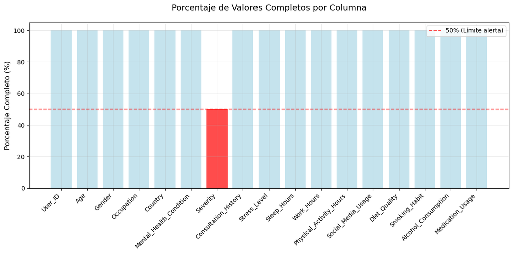

```
Severity: 50.0% completo (!Solo la mitad de los datos!)
```

```python
# Calcular porcentaje de valores completos
completos = (1 - df.isna().mean()) * 100

plt.figure(figsize=(12, 6))
bars = plt.bar(completos.index, completos.values, color='lightblue', alpha=0.7)

# Destacar Severity en rojo
severity_idx = list(completos.index).index('Severity')
bars[severity_idx].set_color('red')

plt.axhline(y=50, color='red', linestyle='--', alpha=0.7, label='50% (Límite alerta)')
plt.title('Porcentaje de Valores Completos por Columna', fontsize=14, pad=20)
plt.ylabel('Porcentaje Completo (%)', fontsize=12)
plt.xticks(rotation=45, ha='right')
plt.ylim(0, 105)
plt.legend()
plt.grid(True, alpha=0.3)
plt.tight_layout()
plt.savefig('fig/valores_completos_simple.png', dpi=150, bbox_inches='tight')
plt.show()

print(f"Severity: {completos['Severity']:.1f}% completo (!Solo la mitad de los datos!)")
```

- El dataset contiene un total de **17 variables** y **50.000 registros**.
- En la revisión de valores nulos (`out/eda_missingness.csv`) se observa que:
- **`Severity`** presenta **25.002 valores nulos**, equivalente al **50,0%** del total.
- Todas las demás variables no presentan valores nulos.
- La variable `Severity` se encuentra **al límite crítico de completitud (50%)**.
- Según estándares de análisis de datos, variables con >40% de nulos suelen considerarse problemáticas, ya que cualquier imputación puede introducir sesgo significativo.
- El patrón de nulos debe analizarse con cuidado: si la ausencia de `Severity` está asociada a otras variables (ej. grupos de edad o nivel de estrés), podría no ser aleatoria (*Missing Not at Random*).
- El resto de variables (`Age`, `Gender`, `Stress_Level`, `Sleep_Hours`, etc.) presentan **completitud del 100%**, lo cual garantiza estabilidad en análisis posteriores.

## 4. Estadísticas descriptivas, test de normalidad y detección de outliers (IQR)

|  | count | mean | std | min | 25% | 50% | 75% | max |
| --- | --- | --- | --- | --- | --- | --- | --- | --- |
| Age | 50000.0 | 41.473080 | 13.844185 | 18.0 | 29.0 | 41.0 | 53.0 | 65.0 |
| Sleep_Hours | 50000.0 | 7.009934 | 1.732674 | 4.0 | 5.5 | 7.0 | 8.5 | 10.0 |
| Work_Hours | 50000.0 | 55.062860 | 14.691575 | 30.0 | 42.0 | 55.0 | 68.0 | 80.0 |
| Physical_Activity_Hours | 50000.0 | 4.982040 | 3.161759 | 0.0 | 2.0 | 5.0 | 8.0 | 10.0 |
| Social_Media_Usage | 50000.0 | 3.243160 | 1.585235 | 0.5 | 1.9 | 3.2 | 4.6 | 6.0 |

|  | variable | n | k2 | p_value |
| --- | --- | --- | --- | --- |
| 0 | Age | 50000 | 44295.063783 | 0.0 |
| 1 | Sleep_Hours | 50000 | 43696.902344 | 0.0 |
| 2 | Work_Hours | 50000 | 42651.238300 | 0.0 |
| 3 | Physical_Activity_Hours | 50000 | 52342.606285 | 0.0 |
| 4 | Social_Media_Usage | 50000 | 42592.964844 | 0.0 |

|  | variable | n | outliers | outliers_pct |
| --- | --- | --- | --- | --- |
| 0 | Age | 50000 | 0 | 0.0 |
| 1 | Sleep_Hours | 50000 | 0 | 0.0 |
| 2 | Work_Hours | 50000 | 0 | 0.0 |
| 3 | Physical_Activity_Hours | 50000 | 0 | 0.0 |
| 4 | Social_Media_Usage | 50000 | 0 | 0.0 |

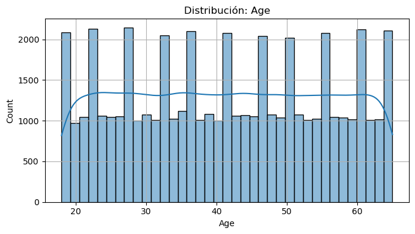

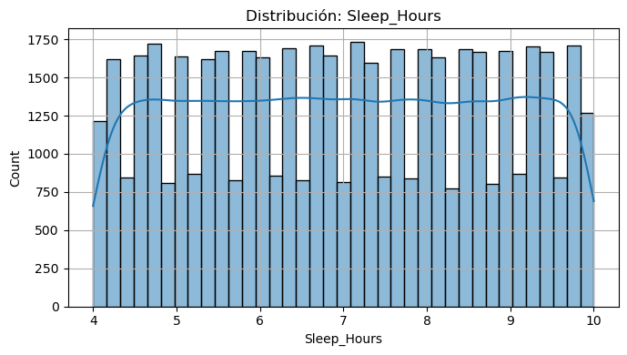

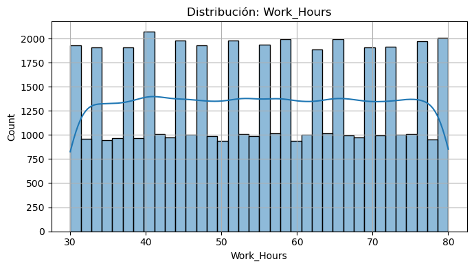

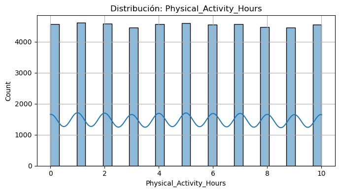

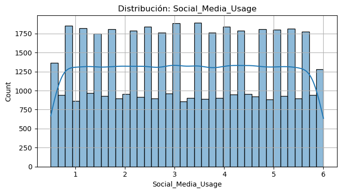

```python
# Descriptivos
desc = df[num_cols].describe().T
display(desc)
desc.to_csv("out/eda_descriptives_numeric.csv")

# Normalidad (D’Agostino K2)
norm_table = []
for c in num_cols:
    s = df[c].dropna()
    if len(s) >= 8:
        k2, p = stats.normaltest(s)
        norm_table.append({"variable": c, "n": len(s), "k2": k2, "p_value": p})
    else:
        norm_table.append({"variable": c, "n": len(s), "k2": np.nan, "p_value": np.nan})
norm_df = pd.DataFrame(norm_table).sort_values("p_value", na_position="last")
display(norm_df)
norm_df.to_csv("out/eda_normality_k2.csv", index=False)

# Outliers por IQR
out_rows = []
for c in num_cols:
    s = df[c].dropna()
    mask = iqr_outlier_mask(s, k=1.5)
    out_rows.append({
        "variable": c,
        "n": len(s),
        "outliers": mask.sum(),
        "outliers_pct": 100*mask.mean()
    })
out_df = pd.DataFrame(out_rows).sort_values("outliers_pct", ascending=False)
display(out_df)
out_df.to_csv("out/eda_outliers_iqr.csv", index=False)

# Distribuciones
for c in num_cols:
    plt.figure()
    sns.histplot(df[c], kde=True, palette="Set2")
    plt.title(f"Distribución: {c}")
    savefig(f"fig/dist_{c}.png")
```

Se evaluaron cinco variables clave que describen aspectos demográficos y de hábitos de vida: `Age`, `Sleep_Hours`, `Work_Hours`, `Physical_Activity_Hours` y `Social_Media_Usage`.

- La edad media (41,5 años) refleja un perfil de **adultos en etapa laboral activa**, con un rango acotado (18–65) que excluye a jóvenes menores de edad y a población mayor. Esto sitúa el análisis en un grupo **socio-laboralmente productivo**, lo que tiene sentido en estudios sobre estrés, salud mental y hábitos de trabajo.
- El promedio de horas de sueño (7h) coincide con la **recomendación médica estándar**, lo cual plantea un punto de interés: ¿se trata de una población con rutinas relativamente saludables o de una autorrepresentación ajustada a normas sociales?
- Las 55 horas promedio de trabajo semanal sitúan a la muestra en condiciones de **alta carga laboral**, muy por encima de la jornada estándar de 40h. Esto abre preguntas sociológicas sobre el impacto de la cultura del trabajo intensivo en el bienestar mental.
- La actividad física (~5h/semana) y el uso de redes sociales (~3h/día) reflejan dimensiones relevantes de la **vida cotidiana** que inciden directamente en salud mental, estilos de vida y socialización.
- El test de normalidad (D’Agostino K²) indicó que **todas las distribuciones son no normales** (p < 0.05).
  - Implicación: se deben aplicar **pruebas no paramétricas** (p. ej. Kruskal-Wallis) en comparaciones entre grupos.
- El análisis de **outliers por IQR** no detectó casos extremos en ninguna de las variables. Esto sugiere que los datos se concentran en intervalos bien definidos y que no hay registros que distorsionen la media o la varianza.
- La ausencia de outliers facilita la **comparación entre cohortes**, pero al mismo tiempo limita la detección de fenómenos extremos (ej. jornadas laborales >80h o uso excesivo de redes sociales >10h/día), que suelen ser relevantes en estudios de salud mental.
1. La concentración de los valores en intervalos razonables **facilita la modelización**, al reducir la necesidad de transformaciones extremas o de limpieza intensiva.
2. La falta de normalidad en las distribuciones obliga a priorizar **métodos robustos** y a evitar supuestos paramétricos en regresiones y tests estadísticos.
3. La homogeneidad de los datos reduce la complejidad de detección de patrones, pero puede limitar la **variabilidad necesaria para identificar perfiles de riesgo diferenciados**.

El análisis de estas cinco variables sugiere que estamos frente a una población adulta laboralmente activa, con niveles de trabajo elevados, rutinas de sueño ajustadas a estándares y hábitos de actividad y socialización dentro de márgenes razonables. Desde un punto de vista metodológico, la **no normalidad y ausencia de outliers** imponen el uso de técnicas robustas y no paramétricas, mientras que desde la perspectiva sociológica los resultados invitan a reflexionar sobre cómo los **estilos de vida intensivos en trabajo y conectividad digital** impactan en la salud mental y la probabilidad de abandono en programas de acompañamiento.

## 5. Distribución de categóricas: Frecuencias y consolidación de categorías menores

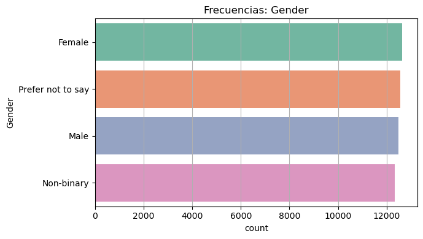

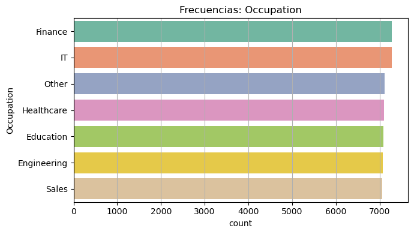

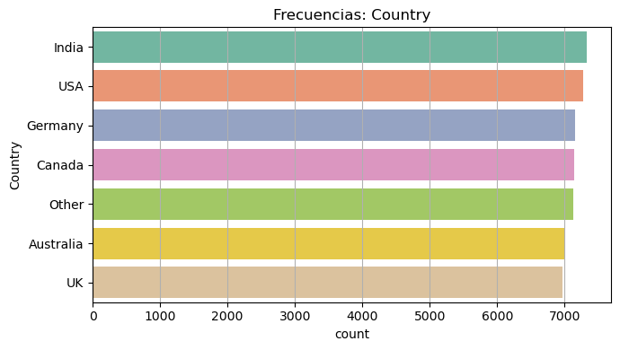

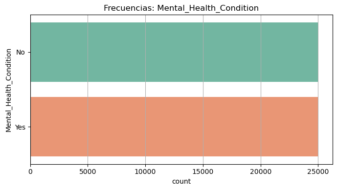

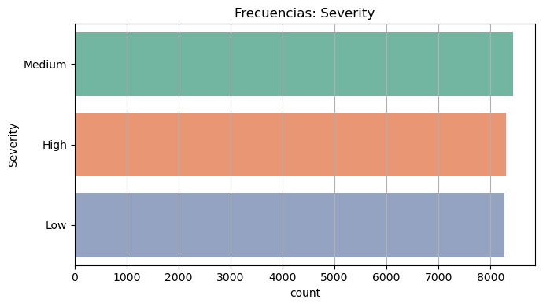

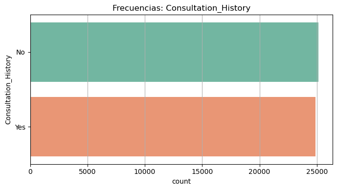

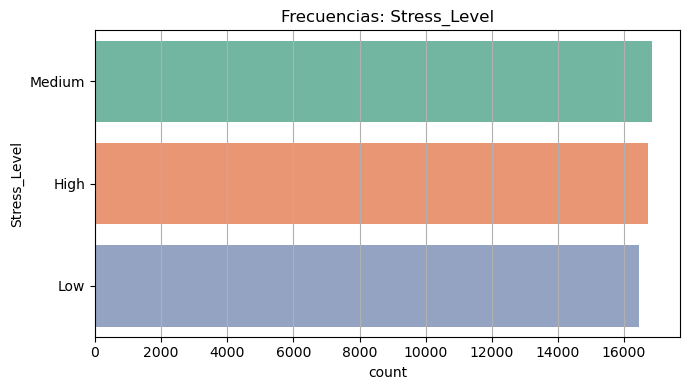

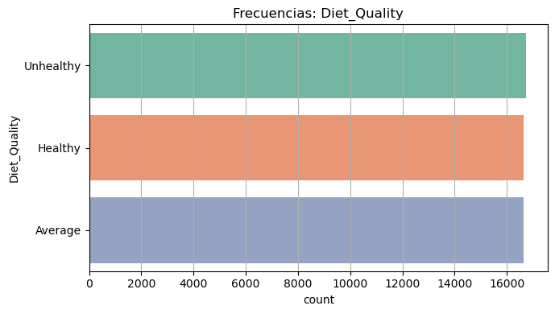

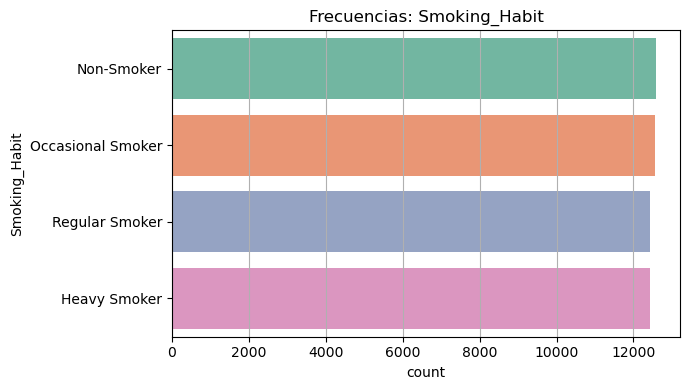

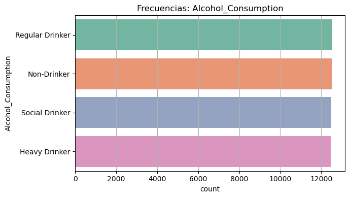

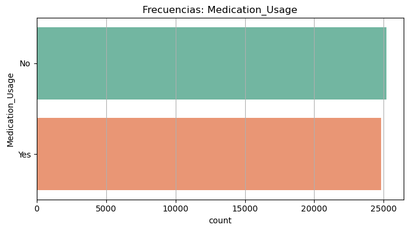

```
[('Gender', 'Gender'),
 ('Occupation', 'Occupation'),
 ('Country', 'Country'),
 ('Mental_Health_Condition', 'Mental_Health_Condition'),
 ('Severity', 'Severity'),
 ('Consultation_History', 'Consultation_History'),
 ('Stress_Level', 'Stress_Level'),
 ('Diet_Quality', 'Diet_Quality'),
 ('Smoking_Habit', 'Smoking_Habit'),
 ('Alcohol_Consumption', 'Alcohol_Consumption'),
 ('Medication_Usage', 'Medication_Usage')]
```

```python
# Agrupación de categorías
def topN_other(series, top=8):
    vc = series.value_counts(dropna=False)
    keep = vc.index[:top]
    return series.where(series.isin(keep), other="Other").astype("category")

cat_summary = []
for c in cat_cols:
    # reagrupa si hay demasiadas categorías
    if df[c].nunique() > 12:
        df[c+"_grp"] = topN_other(df[c], top=10)
        use_col = c + "_grp"
    else:
        use_col = c

    vc = df[use_col].value_counts(dropna=False)
    freq = pd.DataFrame({c: vc.index, "count": vc.values})
    freq["pct"] = 100*freq["count"]/len(df)
    freq.to_csv(f"out/eda_freq_{c}.csv", index=False)
    cat_summary.append((c, use_col))

    # gráfico
    plt.figure()
    sns.countplot(y=df[use_col], order=df[use_col].value_counts().index, palette="Set2")
    plt.title(f"Frecuencias: {use_col}")
    savefig(f"fig/freq_{c}.png")

cat_summary
```

Las variables categóricas aportan una perspectiva rica para combinar análisis cuantitativos y sociológicos sobre los determinantes de abandono en programas de salud mental. La **ausencia de categorías con baja frecuencia** es una ventaja para la robustez estadística, aunque la **alta proporción de datos ausentes en `Severity`** será un aspecto crítico a justificar y tratar metodológicamente en los análisis posteriores.